# Population size structure, not species turnover, tracks environmental gradients across a diverse Indo-Pacific *Pocillopora* assembledge

## Coefficient plot

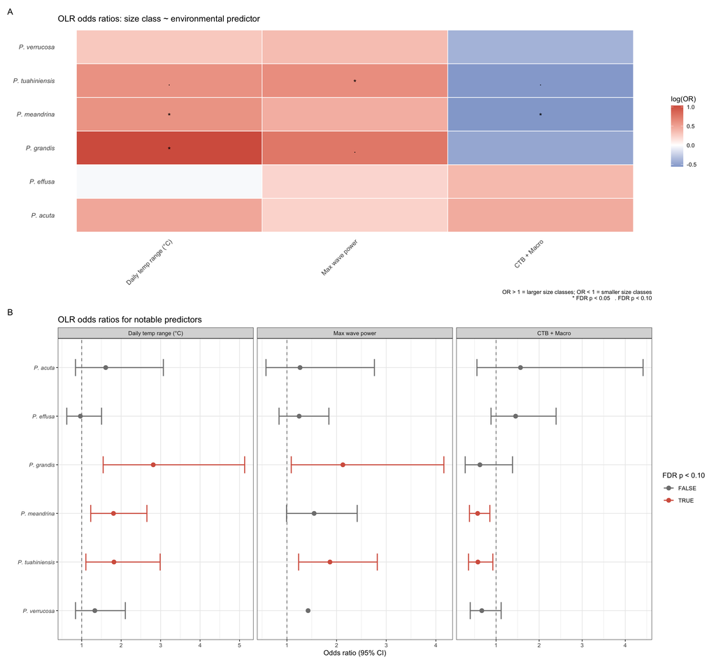

**Figure 4.** Environmental drivers of *Pocillopora* size-class structure from univariate cumulative link mixed models (clmm; site as random intercept; 18 FDR-corrected tests: 6 species × 3 predictors). **A:** Odds ratio (OR) heatmap for all species × predictor combinations. OR > 1 (red) = a 1 SD increase in the predictor is associated with higher probability of a colony being in a larger size class; OR < 1 (blue) = higher probability of a smaller size class. * = FDR p < 0.05, . = FDR p < 0.10. Four combinations reached FDR p < 0.05: *P. grandis* (OR = 2.81) and *P. meandrina* (OR = 1.81) colonies were more likely in larger size classes at sites with greater daily temperature range; *P. tuahiniensis* (OR = 1.87) showed the same pattern with maximum wave power; and *P. meandrina* (OR = 0.57) colonies were more likely in smaller size classes at sites with higher CTB + Macro cover, consistent with macroalgal competition and smothering suppressing larger colony persistence. Three additional combinations were marginal (FDR p < 0.10): *P. tuahiniensis* with daily temperature range (OR = 1.82) and CTB + Macro (OR = 0.58), and *P. grandis* with maximum wave power (OR = 2.13). **B:** OR with 95% CIs for the three predictors with at least one FDR p < 0.10 result.

```r
fig4 <- p_olr_heat / p_olr_coef +
  plot_layout(heights = c(0.9, 1.3)) +
  plot_annotation(tag_levels = "A",
                  theme = theme(plot.tag = element_text(face = "bold", size = 12)))

ggsave(here::here("Output", "Figure4.pdf"), fig4, width = 12, height = 11, units = "in")
ggsave(here::here("Output", "Figure4.jpg"), fig4, width = 12, height = 11, units = "in", dpi = 300)
fig4
```

Daily temperature range remained the strongest and most consistent predictor: a 1 SD increase approximately doubled the odds of a colony being in a larger size class for *P. grandis* (OR = 2.81, 95% CI: 1.54–5.13, FDR p = 0.012) and *P. meandrina* (OR = 1.81, 95% CI: 1.23–2.65, FDR p = 0.017), with a marginal effect in *P. tuahiniensis* (OR = 1.82, 95% CI: 1.11–2.99, FDR p = 0.063). This pattern is consistent with the thermal acclimatization hypothesis — sites with greater daily temperature fluctuation support populations skewed toward adult-dominated size structure — and operates independently of total colony abundance.

Maximum wave power was significantly associated with larger size classes in *P. tuahiniensis* (OR = 1.87, 95% CI: 1.24–2.82, FDR p = 0.017) and marginally in *P. grandis* (OR = 2.13, 95% CI: 1.09–4.16, FDR p = 0.067), consistent with size-selective hydrodynamic dislodgement — smaller colonies are more vulnerable at wave-exposed sites, leaving adult-dominated survivors.

Higher CTB + Macro cover was associated with smaller size classes in *P. meandrina* (OR = 0.57, 95% CI: 0.38–0.86, FDR p = 0.028) and marginally in *P. tuahiniensis* (OR = 0.58, 95% CI: 0.36–0.92, FDR p = 0.063), a negative effect not detectable when CTB and macroalgae were modelled as separate terms. This signal is most consistent with macroalgal competition and smothering suppressing the persistence of larger established colonies, though the composite cannot distinguish this from a CTB-driven recruitment effect on size structure. *P. acuta*, *P. effusa*, and *P. verrucosa* showed no significant associations with any predictor after FDR correction.

**Note**

The proportional odds assumption (that OR is constant across all size-class thresholds) was not formally tested for all models here. For key predictors, this assumption can be checked via `nominal_test()` applied to a `clm()` version of the model with site as a fixed effect. Violations would indicate that the environmental effect differs in magnitude across size-class transitions — itself an ecologically interesting finding warranting a partial proportional odds model.